# Example Model

Author

Shazmeen Maroof

Published

April 12, 2023

## Introduction

This is a hypothetical model predicting house prices. The aim is to show users of the assumptions package and how it can be applied in their model.

We are using data on *‘House Price Statistics for Small Areas’* as an example. This example dataset is stored in the data folder with the file name: *Housing_data.xlsx*

Below is a screenshot of what the data looks like:

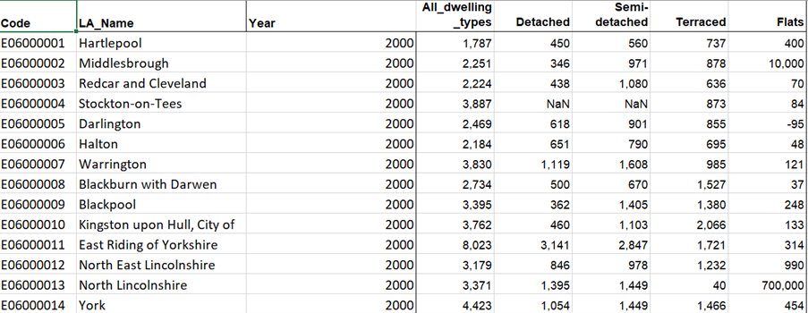

## Assumptions

The model has three assumptions

## Assumption recording

This section shows how each assumption should be stored in code.

1. House price should always be a positive number.

```python
# Assumption: House price should always be a positive number.
# Quality: RED
# Impact: AMBER
# Detailed description: We assume that no house is sold for a negative amount or for no value.

import numpy as np
import pandas as pd
housing_sale_price = pd.read_excel("D:\\git_demo\\Data/Housing_data.xlsx", sheet_name="median_sale_price")

# convert an individual column in the dataframe into a list
All_dwelling_types = housing_sale_price['All_dwelling_types'].values.tolist()

def find_negatives(All_dwelling_types):
  for num in All_dwelling_types:
    if num < 0:
      print(num, end=" ")
      return False
    else:
      return True

# printing the result
print(find_negatives(All_dwelling_types))
```

```
-47000.0 False
```

2. Current trends in price will continue.

```python
# Assumption: Current trends in price will continue.
# Quality: RED
# Impact: AMBER
# Detailed description: We assume that the median sale price of each dwelling type in a local authority in time 't' should be less than time 't+1'.
```

```python
# Assumption: There is regional variation in house prices.
# Quality: RED
# Impact: AMBER
# Detailed description: Median house prices of all dwelling types in London exceeds median house prices for every other region in England and Wales each year.
```

## Assumption Documentation

After installing the assumptions’ package and passing the code *‘assumptions’*, an example assumptions’ log will be created within the same folder. Open the newly created file on *‘assumptions_caveats_log.md’* to see the example output on assumptions’ log.

The readme file explains the installation steps and the step-by-step process on how to go from this code to the output document on assumptions’ log.

## Assumption Sign-off

Since the file storing these assumptions i.e., example_code.py gets pushed to Github, there will be a review every time a new assumption is added and tested. As such, sign off is built into the process.

## Conclusion

Assumptions’ package will produce a markdown document on assumptions’ log. Once properly setup, its quick and easy to use. The log will show the location of stored assumptions, their quality rating and description. The package will take care of automatically updating the assumptions during the project lifecycle and Github will track the sign-offs of assumptions.

## Software requirements

Python, VSCode, Github

## Useful links

Link to the package: https://assumptions.readthedocs.io/en/latest/usage.html  
Github set up guidance: https://docs.github.com/en/get-started/quickstart/set-up-git  
Link to VSCode installation guide: https://gitlab-app-l-01/ASAP/coding-getting-started-guide/-/wikis/code-editors  
Link to pip installation: https://gitlab-app-l-01/ASAP/coding-getting-started-guide/-/wikis/python

## Places to get help

ASAP@ons.gov.uk